# Reproducible Research: Peer Assessment 1

## Loading and preprocessing the data

```r
# File names (as constants)
chrFile_input <- "activity.zip"
chrFile_read <- "activity.csv"
# First unzip the data, it's already in the GIT repository conatining this document
unzip (chrFile_input)
# Read the data.
dfStep_data <- read.csv(chrFile_read)
```

## What is mean total number of steps taken per day?

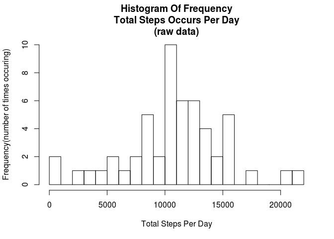

```r
# Calculate the total number of steps per day(first form of tapply causes problems so is commented out)
#numSteps_day = tapply(dfStep_data$steps,dfStep_data$date,FUN=sum,na.rm=TRUE)
numSteps_day = tapply(dfStep_data$steps,dfStep_data$date,FUN=sum)
# Generate the new mean & median  steps per day, ready to be inserted inline in commentary
numSteps_mean <- as.integer(mean(numSteps_day, na.rm=TRUE))
numSteps_median <- as.integer(median(numSteps_day, na.rm=TRUE))
# Then plot a histogram
hist(numSteps_day,20,
     main="Histogram Of Frequency\nTotal Steps Occurs Per Day\n(raw data)",
     xlab="Total Steps Per Day",ylab="Frequency(number of times occuring)")
```

The mean of the total number of steps per day is 10766 and the median of the total number of steps per day is 10765

## What is the average daily activity pattern?

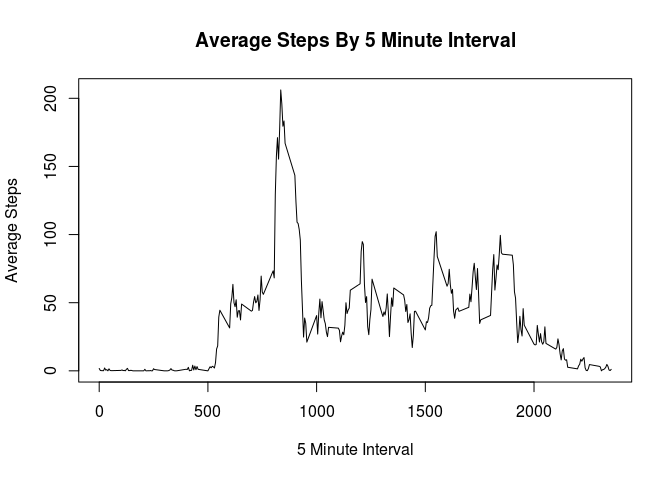

```r
# Generate base data
numAve_steps_interval <- tapply(dfStep_data$steps,dfStep_data$interval,FUN=mean,na.rm=TRUE)
# Which 5 minute time-period averages max steps
numIndex <- which.max(numAve_steps_interval) # Find index to Max steps
chrIntervals <- levels (as.factor(dfStep_data$interval))
numMax_steps <- as.integer(max(numAve_steps_interval))
numMax_occurs_at <- chrIntervals[numIndex]
# Plot the data
plot(levels (as.factor(dfStep_data$interval)), numAve_steps_interval, type="l",
     main="Average Steps By 5 Minute Interval",
     xlab="5 Minute Interval", ylab="Average Steps")
```

As can be seen in the chart above, a big activity peak occurs in the morning

The maximum number of steps (on average) is 206 and occurs in the 5 minute interval starting at 835

## Imputing missing values

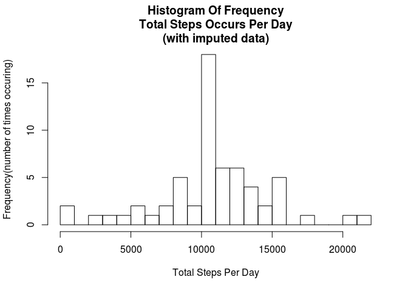

```r
# Calculate total number of NAs
numNas <- sum(is.na(dfStep_data$steps))

# Impute missing data - use overall average for that 5 minute interval (rounded to integer)
dfStep_data_imp <- dfStep_data
for (i in 1:length(numAve_steps_interval)){
    dfStep_data_imp$steps[dfStep_data_imp$interval==chrIntervals[i] &
                              is.na(dfStep_data_imp$steps)] <- round(numAve_steps_interval[i],0)
}

# Generate the new mean & median  steps per day, ready to be inserted inline in commentary
numSteps_day_imp = tapply(dfStep_data_imp$steps,dfStep_data_imp$date,FUN=sum,na.rm=TRUE)
numSteps_mean_imp <- as.integer(mean(numSteps_day_imp, na.rm=TRUE))
numSteps_median_imp <- as.integer(median(numSteps_day_imp, na.rm=TRUE))

# Create a new Hist
hist(numSteps_day_imp,20,
     main="Histogram Of Frequency\nTotal Steps Occurs Per Day\n(with imputed data)",
     xlab="Total Steps Per Day",ylab="Frequency(number of times occuring)")
```

There were 2304 NAs in the raw data.

Once NAs are replaced with imputed data (ie. with the average for that 5 minute time period)  
1. The new mean steps per day is 10765 (vs 10766 previously)  
2. The new median steps per day is 10762 (vs 10765 previously)

We can see that the mean and median number of steps per day have barely changed once data is “imputed”. This reflects the fact that we have replaced NA with the mean.

NOTE: Imputed data is  
1. Based on the 5 minute intervals  
2. Imputed values are for intervals where the “number of steps” value is NA  
3. Values assigned are the rounded integer value of the average number of steps for that 5 minute interval

## Are there differences in activity patterns between weekdays and weekends?

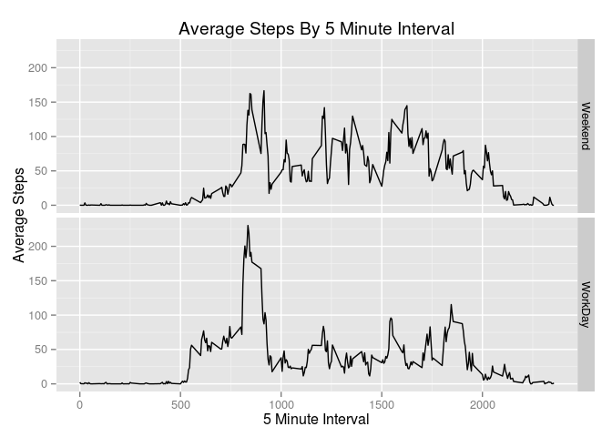

```r
# Compare weekday activity to weekends
# Start by categorising days as either weekday or weekend
library(lubridate, warn.conflicts=FALSE)  # Date handling, myd function
dfStep_data_imp$day_type <- rep("WorkDay",length(dfStep_data_imp$date))
dfStep_data_imp$day_type[weekdays(ymd(as.character(dfStep_data_imp$date)))
                         %in% c("Saturday","Sunday")] <- "Weekend"
dfStep_data_imp$day_type <- as.factor(dfStep_data_imp$day_type)
# Create the data to be used for plots, a summary of steps by day-type and 5-minute-interval
library("data.table", warn.conflicts=FALSE)    # Data table handling, for Aggregate function
numAve_steps_interval_imp <- tapply(dfStep_data_imp$steps,dfStep_data_imp$interval,FUN=mean,na.rm=TRUE)
dfPlot_final <- aggregate.data.frame(dfStep_data_imp$steps,
                        list(dfStep_data_imp$interval, dfStep_data_imp$day_type), FUN=mean)
names(dfPlot_final) <- c("interval","day_type","AveSteps")
# Create the plot (2 plots one above the other)
library(ggplot2, warn.conflicts=FALSE)  # Plotting
qp <- qplot(interval, AveSteps, data=dfPlot_final,facets=day_type ~ .,geom="line",
            main="Average Steps By 5 Minute Interval",
            xlab="5 Minute Interval",ylab="Average Steps")
print (qp)
```

as can be seen from the graphs above -  
1) There’s a major activity peak on weekday mornings which is delayed and moderated on a weekend  
2) Weekend activity starts later, is more evenly distributed through the day and continues a little longer into the evening